# Análisis de Datos y Predictor de Eventos Coronarios

Author: Gonzalo Mato, Lucas Cayol, Pedro Castillo y Santiago Barra

### Introducción

Se elaboró una herramienta para uso médico y con motivo de dar un diagnóstico temprano de eventos coronarios para los pacientes que se presentan en la guardia de un hospital.

## Relación Entre Síndromes Anginosos y Eventos Coronarios

En este grafico se analizó si el presentar síntomas anginosos aumenta la probabilidad de tener eventos coronarios. Los resultados muestran que, aunque el porcentaje es significativo, no es muy probable que tener síntomas anginosos lleve a tener eventos coronarios.

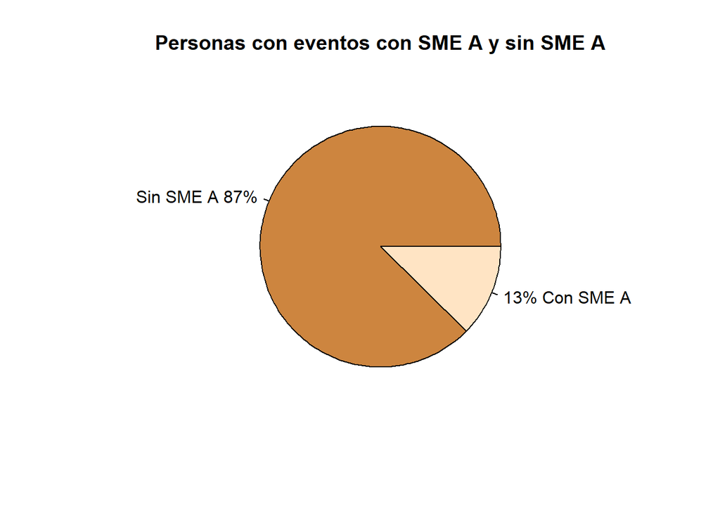

## Eventos Coronarios Segun Edad y Genero

Al interpretar los gráficos se puede ver que los hombres tienen un pico estable dentro de los 30 y 40 años, mientras que las mujeres presentan un pico más pronunciado de eventos dentro del mismo rango de edad. Con los datos de la tabla analizamos que 4 de cada 5 pacientes que ingresan al hospital con eventos coronarios son hombres.

|  | Hombres | Mujeres |
| --- | --- | --- |
| Número de pacientes con eventos | 97 | 24 |
| Pico máximo de edad | 87 | 80 |

### Pacientes masculinos que presentan eventos

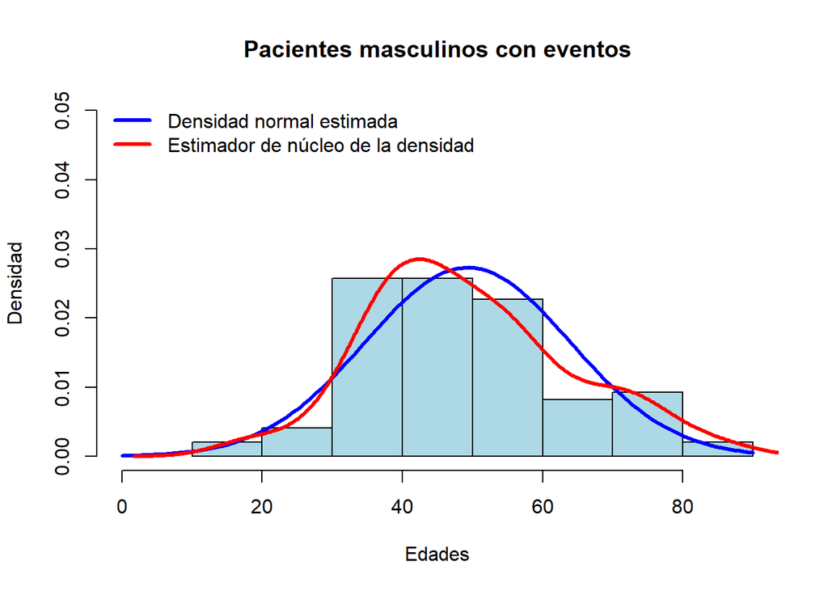

### Pacientes femeninos que presentan eventos

[figure not shown]

## Los Diabéticos, los Obesos y la Hipertensión Arterial

### Diabéticos obesos

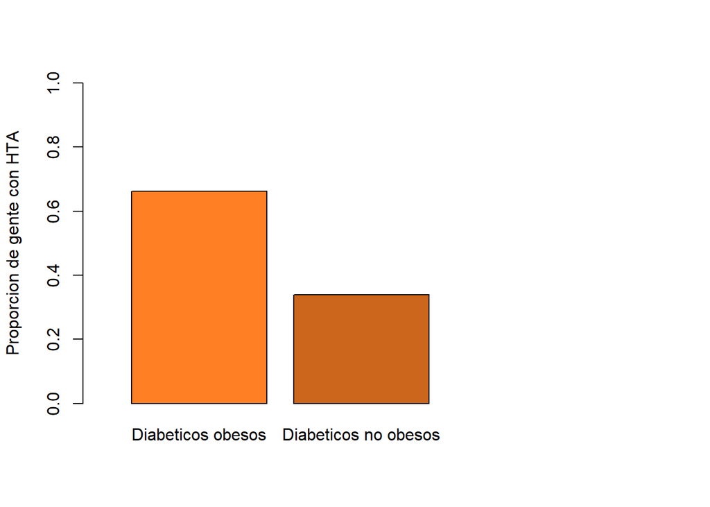

Buscamos la relación entra la obesidad y la tendencia a tener diabetes. Y como a su vez ese grupo de personas tiene a tener HTA

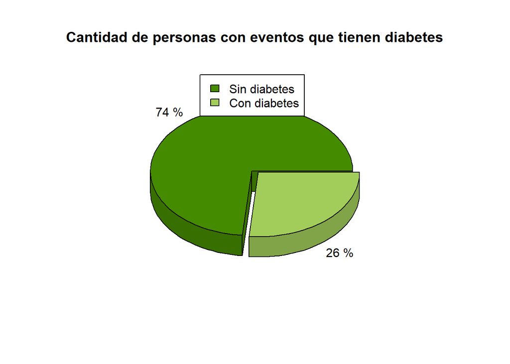

Teniendo en cuenta los datos anteriores comparamos la tendencia de la diabetes a los eventos cardiacos.

## Relación entre Fumadores y Obesos

Se analizó la relación de los pacientes que tienen obesidad y que son fumadores, en cuanto a la tendencia de tener eventos cardiacos. La base de datos de pacientes no define si son fumadores activos o pasivos, por lo cual se agruparon ambos.

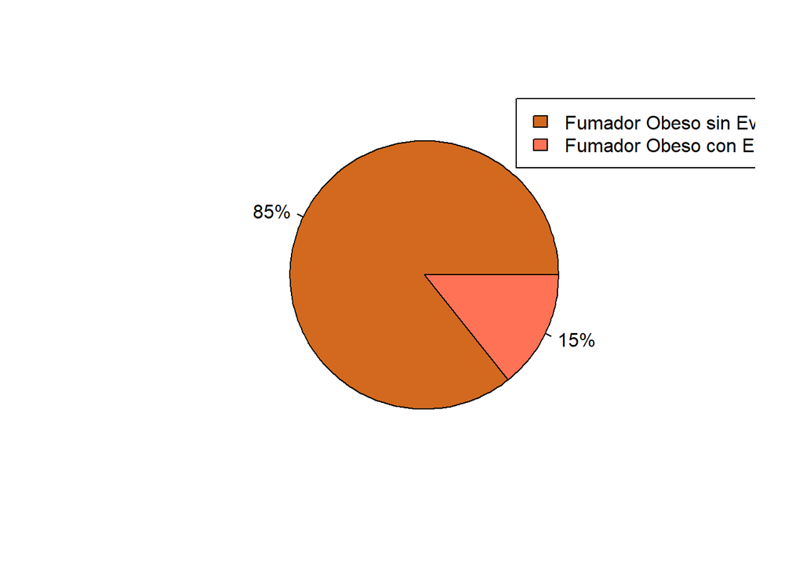